# Project 1

Stephanie Hicks

Department of Biostatistics, Johns Hopkins

2022-09-06

# Background

**Due date: Sept 16 at 11:59pm**

### To submit your project

Please write up your project using R Markdown and `knitr`. Compile your document as an **HTML file** and submit your HTML file to the dropbox on Courseplus. Please **show all your code** for each of the answers to each part.

To get started, [watch this video on setting up your R Markdown document](https://www.stephaniehicks.com/jhustatcomputing2021/posts/2021-09-02-literate-programming/#create-and-knit-your-first-r-markdown-document).

### Install `tidyverse`

Before attempting this assignment, you should first install the `tidyverse` package if you have not already. The `tidyverse` package is actually a collection of many packages that serves as a convenient way to install many packages without having to do them one by one. This can be done with the `install.packages()` function.

```r
install.packages("tidyverse")
```

Running this function will install a host of other packages so it make take a minute or two depending on how fast your computer is. Once you have installed it, you will want to load the package.

```r
library(tidyverse)
```

### Data

That data for this part of the assignment comes from [TidyTuesday](https://www.tidytuesday.com), which is a weekly podcast and global [community activity](https://github.com/rfordatascience/tidytuesday) brought to you by the R4DS Online Learning Community. The goal of TidyTuesday is to help R learners learn in real-world contexts.

[figure not shown]

$$**Source**:
[TidyTuesday](https://github.com/rfordatascience/tidytuesday/blob/master/static/tt_logo.png)$$

If we look at the [TidyTuesday github repo](https://github.com/rfordatascience/tidytuesday/tree/master/data/2022#2022-data) from 2022, we see this dataset chocolate bar reviews.

To access the data, you need to install the `tidytuesdayR` R package and use the function `tt_load()` with the date of ‘2022-01-18’ to load the data.

```r
install.packages("tidytuesdayR")
```

This is how you can download the data.

```r
tuesdata <- tidytuesdayR::tt_load('2022-01-18')
chocolate <- tuesdata$chocolate
```

However, if you use this code, you will hit an API limit after trying to compile the document a few times. Instead, I suggest you use the following code below. Here, I provide the code below for you to avoid re-downloading data:

```r
library(here)
library(tidyverse)

# tests if a directory named "data" exists locally
if(!dir.exists(here("data"))) { dir.create(here("data")) }

# saves data only once (not each time you knit a R Markdown)
if(!file.exists(here("data","chocolate.RDS"))) {
  url_csv <- 'https://raw.githubusercontent.com/rfordatascience/tidytuesday/master/data/2022/2022-01-18/chocolate.csv'
  chocolate <- readr::read_csv(url_csv)

  # save the file to RDS objects
  saveRDS(chocolate, file= here("data","chocolate.RDS"))
}
```

Here we read in the `.RDS` dataset locally from our computing environment:

```r
chocolate <- readRDS(here("data","chocolate.RDS"))
as_tibble(chocolate)
```

```
## # A tibble: 2,530 × 10
##      ref compan…¹ compa…² revie…³ count…⁴ speci…⁵ cocoa…⁶ ingre…⁷ most_…⁸ rating
##    <dbl> <chr>    <chr>     <dbl> <chr>   <chr>   <chr>   <chr>   <chr>    <dbl>
##  1  2454 5150     U.S.A.     2019 Tanzan… Kokoa … 76%     3- B,S… rich c…   3.25
##  2  2458 5150     U.S.A.     2019 Domini… Zorzal… 76%     3- B,S… cocoa,…   3.5
##  3  2454 5150     U.S.A.     2019 Madaga… Bejofo… 76%     3- B,S… cocoa,…   3.75
##  4  2542 5150     U.S.A.     2021 Fiji    Matasa… 68%     3- B,S… chewy,…   3
##  5  2546 5150     U.S.A.     2021 Venezu… Sur de… 72%     3- B,S… fatty,…   3
##  6  2546 5150     U.S.A.     2021 Uganda  Semuli… 80%     3- B,S… mildly…   3.25
##  7  2542 5150     U.S.A.     2021 India   Anamal… 68%     3- B,S… milk b…   3.5
##  8   797 A. Morin France     2012 Bolivia Bolivia 70%     4- B,S… vegeta…   3.5
##  9   797 A. Morin France     2012 Peru    Peru    63%     4- B,S… fruity…   3.75
## 10  1011 A. Morin France     2013 Panama  Panama  70%     4- B,S… brief …   2.75
## # … with 2,520 more rows, and abbreviated variable names ¹company_manufacturer,
## #   ²company_location, ³review_date, ⁴country_of_bean_origin,
## #   ⁵specific_bean_origin_or_bar_name, ⁶cocoa_percent, ⁷ingredients,
## #   ⁸most_memorable_characteristics
```

We can take a glimpse at the data

```r
glimpse(chocolate)
```

```
## Rows: 2,530
## Columns: 10
## $ ref                              <dbl> 2454, 2458, 2454, 2542, 2546, 2546, 2…
## $ company_manufacturer             <chr> "5150", "5150", "5150", "5150", "5150…
## $ company_location                 <chr> "U.S.A.", "U.S.A.", "U.S.A.", "U.S.A.…
## $ review_date                      <dbl> 2019, 2019, 2019, 2021, 2021, 2021, 2…
## $ country_of_bean_origin           <chr> "Tanzania", "Dominican Republic", "Ma…
## $ specific_bean_origin_or_bar_name <chr> "Kokoa Kamili, batch 1", "Zorzal, bat…
## $ cocoa_percent                    <chr> "76%", "76%", "76%", "68%", "72%", "8…
## $ ingredients                      <chr> "3- B,S,C", "3- B,S,C", "3- B,S,C", "…
## $ most_memorable_characteristics   <chr> "rich cocoa, fatty, bready", "cocoa, …
## $ rating                           <dbl> 3.25, 3.50, 3.75, 3.00, 3.00, 3.25, 3…
```

Here is a data dictionary for what all the column names mean:

- https://github.com/rfordatascience/tidytuesday/blob/master/data/2022/2022-01-18/readme.md#data-dictionary

# Part 1: Explore data

In this part, use functions from `dplyr` and `ggplot2` to answer the following questions.

1. Make a histogram of the `rating` scores to visualize the overall distribution of scores. Change the number of bins from the default to 10, 15, 20, and 25. Pick on the one that you think looks the best. Explain what the difference is when you change the number of bins and explain why you picked the one you did.

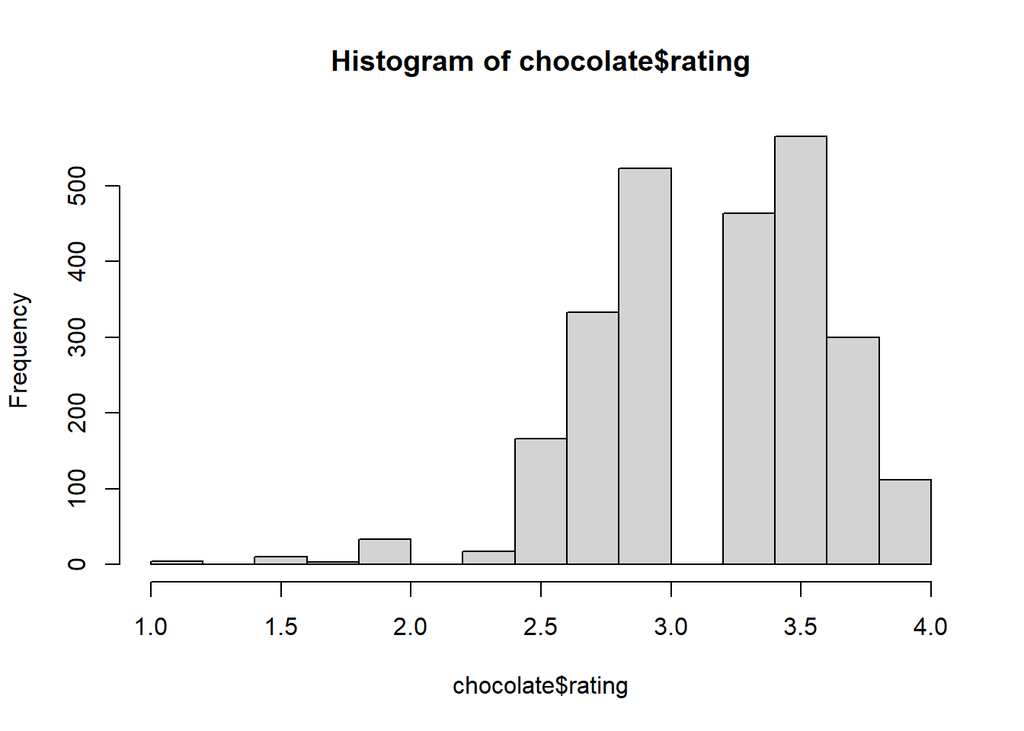

```r
# Add your solution here and describe your answer afterwards
hist(chocolate$rating)
hist(chocolate$rating, breaks=15)
```

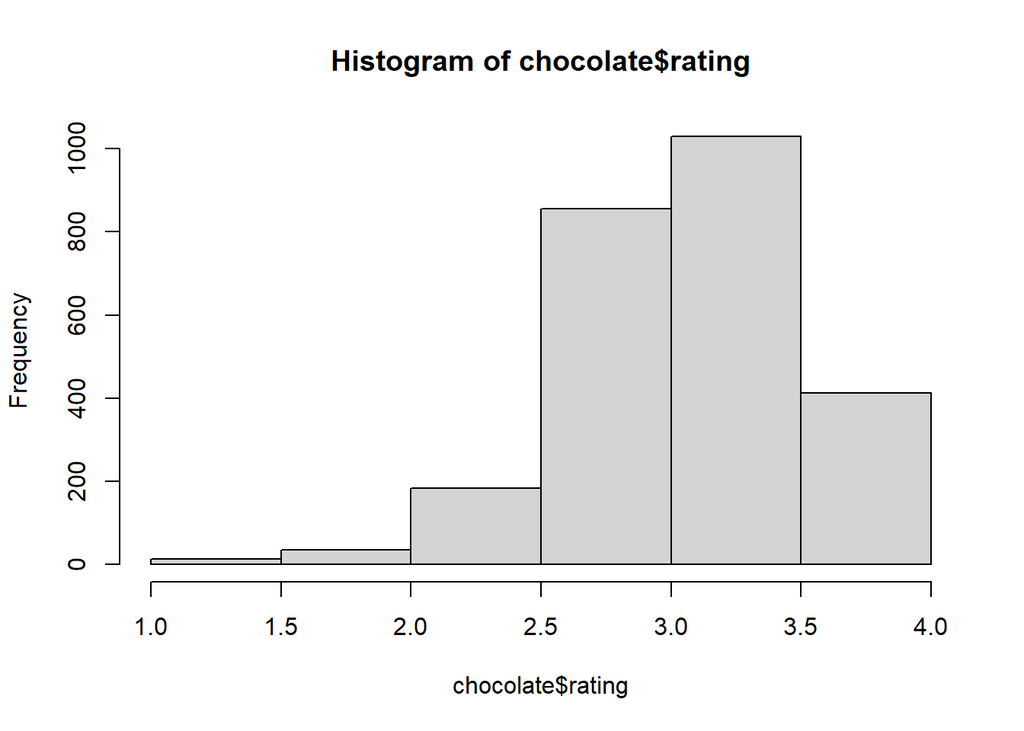

```r
hist(chocolate$rating, breaks=10)
```

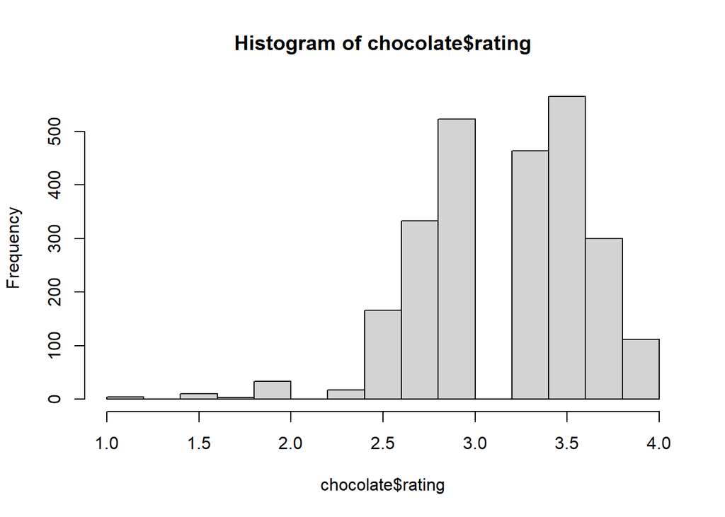

```r
hist(chocolate$rating, breaks=15)
hist(chocolate$rating, breaks=20)
```

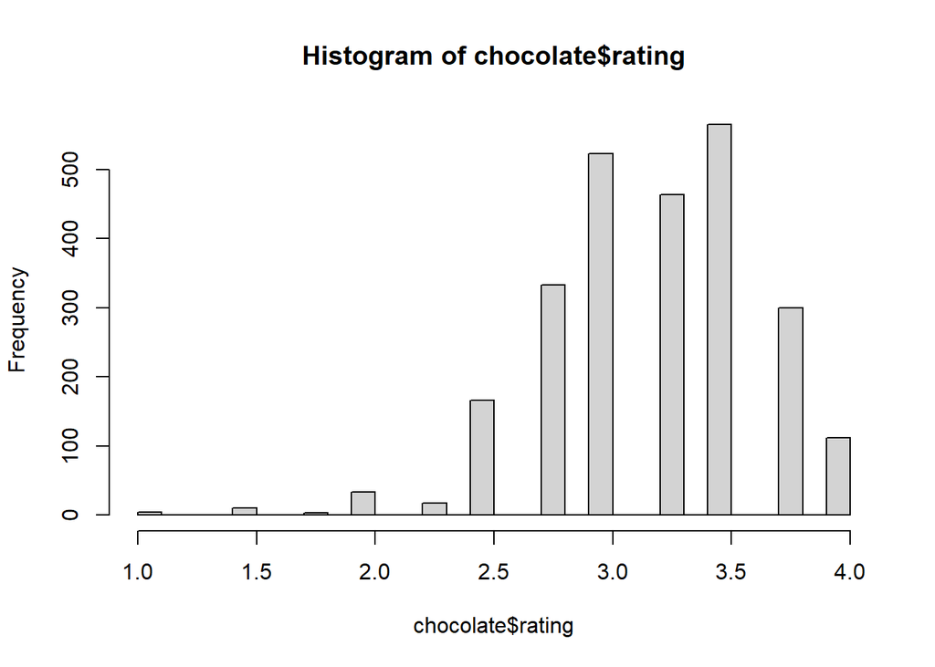

```r
hist(chocolate$rating, breaks=25)
```

```r
#I would go with bin= 10 as it removes gaps and helps me to better visualize histogram
```

2. Consider the countries where the beans originated from. How many reviews come from each country of bean origin?

```r
##2. Reviews rating to each countries bean origin
rat_origin <- group_by(chocolate, country_of_bean_origin)
rat_origin1 <- summarize(rat_origin, count= n())

rat_origin2 <- as_tibble(rat_origin1)
str(rat_origin2)
```

```
## tibble [62 × 2] (S3: tbl_df/tbl/data.frame)
##  $ country_of_bean_origin: chr [1:62] "Australia" "Belize" "Blend" "Bolivia" ...
##  $ count                 : int [1:62] 3 76 156 80 78 1 3 1 79 11 ...
```

3. What is average `rating` scores from reviews of chocolate bars that have Ecuador as `country_of_bean_origin` in this dataset? For this same set of reviews, also calculate (1) the total number of reviews and (2) the standard deviation of the `rating` scores. Your answer should be a new data frame with these three summary statistics in three columns. Label the name of these columns `mean`, `sd`, and `total`.

```r
##3. Ecuador rating
ecu<- chocolate[chocolate$country_of_bean_origin %in% c("Ecuador"),]

ecu1<- group_by(ecu,country_of_bean_origin ) %>%
  summarize(total= n(), mean= mean(rating, na.rm=TRUE), sd= sd(rating, na.rm= TRUE))
```

4. Which country makes the best chocolate (or has the highest ratings on average) with beans from Ecuador?

```r
##4. Best chocolate with beans from Ecuador
best<- group_by(ecu, company_location) %>%
   summarize (total= n(), avgrat = mean(rating, na.rm = TRUE))
best1<- best %>% filter(avgrat== max(avgrat, na.rm=TRUE))
```

5. Calculate the average rating across all country of origins for beans. Which top 3 countries have the highest ratings on average?

```r
##5. Top 3 countries across all country of origins for beans

top_3_countries <- group_by(chocolate, country_of_bean_origin) %>%
 summarise(total= n(), avg= mean(rating, na.rm=TRUE)) %>%
 arrange(desc(avg)) %>%
 slice(1:3)
```

6. Following up on the previous problem, now remove any countries of bean origins that have less than 10 chocolate bar reviews. Now, which top 3 countries have the highest ratings on average?
7. For this last part, let’s explore the relationship between percent chocolate and ratings.

Use the functions in `dplyr`, `tidyr`, and `lubridate` to perform the following steps to the `chocolate` dataset:

1. Identify the countries of bean origin with at least 50 reviews. Remove reviews from countries are not in this list.
2. Using the variable describing the chocolate percentage for each review, create a new column that groups chocolate percentages into one of four groups: (i) <60%, (ii) >=60 to <70%, (iii) >=70 to <90%, and (iii) >=90% (**Hint** check out the `substr()` function in base R and the `case_when()` function from `dplyr` – see example below).
3. Using the new column described in #2, re-order the factor levels (if needed) to be starting with the smallest percentage group and increasing to the largest percentage group (**Hint** check out the `fct_relevel()` function from `forcats`).
4. For each country, make a set of four side-by-side boxplots plotting the groups on the x-axis and the ratings on the y-axis. These plots should be faceted by country.

On average, which category of chocolate percentage is most highly rated? Do these countries mostly agree or are there disagreements?

**Hint**: You may find the `case_when()` function useful in this part, which can be used to map values from one variable to different values in a new variable (when used in a `mutate()` call).

```r
## Generate some random numbers
dat <- tibble(x = rnorm(100))
slice(dat, 1:3)
```

```
## # A tibble: 3 × 1
##         x
##     <dbl>
## 1 -0.291
## 2 -0.793
## 3  0.0682
```

```r
## Create a new column that indicates whether the value of 'x' is positive or negative
dat %>%
        mutate(is_positive = case_when(
                x >= 0 ~ "Yes",
                x < 0 ~ "No"
        ))
```

```
## # A tibble: 100 × 2
##          x is_positive
##      <dbl> <chr>
##  1 -0.291  No
##  2 -0.793  No
##  3  0.0682 Yes
##  4  0.356  Yes
##  5  1.05   Yes
##  6  1.71   Yes
##  7 -0.155  No
##  8  0.537  Yes
##  9  0.745  Yes
## 10  0.289  Yes
## # … with 90 more rows
```

# Part 2: Join two datasets together

The goal of this part of the assignment is to join two datasets together. `gapminder` is a [R package](https://cran.r-project.org/web/packages/gapminder/README.html) that contains an excerpt from the [Gapminder data](https://www.gapminder.org/data/).

### Tasks

1. Use this dataset it to create a new column called `continent` in our `chocolate` dataset that contains the continent name for each review where the country of bean origin is.
2. Only keep reviews that have reviews from countries of bean origin with at least 10 reviews.
3. Also, remove the country of bean origin named `"Blend"`.
4. Make a set of violin plots with ratings on the y-axis and `continent`s on the x-axis.

**Hint**:

- Check to see if there are any `NA`s in the new column. If there are any `NA`s, add the continent name for each row.

```r
###Part 2
#Joining gapminder continent column
library(gapminder)
gapminder
```

```
## # A tibble: 1,704 × 6
##    country     continent  year lifeExp      pop gdpPercap
##    <fct>       <fct>     <int>   <dbl>    <int>     <dbl>
##  1 Afghanistan Asia       1952    28.8  8425333      779.
##  2 Afghanistan Asia       1957    30.3  9240934      821.
##  3 Afghanistan Asia       1962    32.0 10267083      853.
##  4 Afghanistan Asia       1967    34.0 11537966      836.
##  5 Afghanistan Asia       1972    36.1 13079460      740.
##  6 Afghanistan Asia       1977    38.4 14880372      786.
##  7 Afghanistan Asia       1982    39.9 12881816      978.
##  8 Afghanistan Asia       1987    40.8 13867957      852.
##  9 Afghanistan Asia       1992    41.7 16317921      649.
## 10 Afghanistan Asia       1997    41.8 22227415      635.
## # … with 1,694 more rows
```

```r
joined_tibble<- chocolate %>% left_join(gapminder, by= c("country_of_bean_origin"= "country"), copy= TRUE)


#removing <10 reviews
joined_tibble2 <- group_by(joined_tibble,country_of_bean_origin, rating, continent) %>%   summarise(total= n())
```

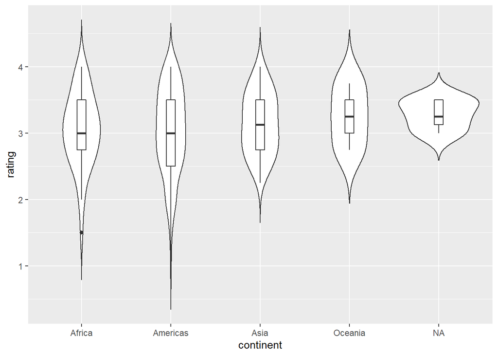

```r
#filter n>= 10 and remove blend
jt_more10wB <- filter(joined_tibble2, country_of_bean_origin != "Blend", total >=10)

#voilen plot
p <- ggplot(jt_more10wB, aes(x=continent, y=rating)) +
     geom_violin(trim= FALSE)
#Print p
p + geom_boxplot(width=0.1)
```

# Part 3: Convert wide data into long data

The goal of this part of the assignment is to take a dataset that is either messy or simply not tidy and to make them tidy datasets. The objective is to gain some familiarity with the functions in the `dplyr`, `tidyr` packages. You may find it helpful to review the section on spreading and gathering data.

### Tasks

We are going to create a set of features for us to plot over time. Use the functions in `dplyr` and `tidyr` to perform the following steps to the `chocolate` dataset:

1. Create a new set of columns titled `beans`, `sugar`, `cocoa_butter`, `vanilla`, `letchin`, and `salt` that contain a 1 or 0 representing whether or not that review for the chocolate bar contained that ingredient (1) or not (0).
2. Create a new set of columns titled `char_cocoa`, `char_sweet`, `char_nutty`, `char_creamy`, `char_roasty`, `char_earthy` that contain a 1 or 0 representing whether or not that the most memorable characteristic for the chocolate bar had that word (1) or not (0). For example, if the word “sweet” appears in the `most_memorable_characteristics`, then record a 1, otherwise a 0 for that review in the `char_sweet` column (**Hint**: check out `str_detect()` from the `stringr` package).
3. For each year (i.e. `review_date`), calculate the mean value in each new column you created across all reviews for that year. (**Hint**: If all has gone well thus far, you should have a dataset with 16 rows and 13 columns).
4. Convert this wide dataset into a long dataset with a new `feature` and `mean_score` column.

It should look something like this:

```
review_date     feature   mean_score
<dbl>           <chr>     <dbl>
2006    beans   0.967741935
2006    sugar   0.967741935
2006    cocoa_butter    0.903225806
2006    vanilla 0.693548387
2006    letchin 0.693548387
2006    salt    0.000000000
2006    char_cocoa  0.209677419
2006    char_sweet  0.161290323
2006    char_nutty  0.032258065
2006    char_creamy 0.241935484
```

### Notes

- You may need to use functions outside these packages to obtain this result.
- Do not worry about the ordering of the rows or columns. Depending on whether you use `gather()` or `pivot_longer()`, the order of your output may differ from what is printed above. As long as the result is a tidy data set, that is sufficient.

```r
###Part 3
##1. Ingredients
#Creating new column for beans
chocolate$beans <- str_detect(chocolate$ingredients, "B")
#Checking if beans are present or not
chocolate$beans <- as.integer(chocolate$beans)
#replacing NA in dataframe
chocolate$beans[is.na(chocolate$beans)] <- 0
summary(chocolate$beans)
```

```
##    Min. 1st Qu.  Median    Mean 3rd Qu.    Max.
##  0.0000  1.0000  1.0000  0.9656  1.0000  1.0000
```

```r
#Creating new column for cocoa butter and replacing
chocolate$cocoa <- str_detect(chocolate$ingredients, "C")
chocolate$cocoa <- as.integer(chocolate$cocoa)
chocolate$cocoa[is.na(chocolate$cocoa)] <- 0
summary(chocolate$cocoa)
```

```
##    Min. 1st Qu.  Median    Mean 3rd Qu.    Max.
##  0.0000  0.0000  1.0000  0.6593  1.0000  1.0000
```

```r
#Creating new column for sugar and replacing
chocolate$sugar <- str_detect(chocolate$ingredients, "S")
chocolate$sugar <- as.integer(chocolate$sugar)
chocolate$sugar[is.na(chocolate$sugar)] <- 0
summary(chocolate$sugar)
```

```
##    Min. 1st Qu.  Median    Mean 3rd Qu.    Max.
##  0.0000  1.0000  1.0000  0.9628  1.0000  1.0000
```

```r
#Creating new column for Vanilla and replacing
chocolate$vanilla <- str_detect(chocolate$ingredients, "V")
chocolate$vanilla <- as.integer(chocolate$vanilla)
#replacing NA in dataframe
chocolate$vanilla[is.na(chocolate$vanilla)] <- 0
summary(chocolate$vanilla)
```

```
##    Min. 1st Qu.  Median    Mean 3rd Qu.    Max.
##  0.0000  0.0000  0.0000  0.1395  0.0000  1.0000
```

```r
#creating new column for letchin and replacing
chocolate$letchin <- str_detect(chocolate$ingredients, "L")
chocolate$letchin <- as.integer(chocolate$letchin)
chocolate$letchin[is.na(chocolate$letchin)] <- 0
summary(chocolate$letchin)
```

```
##    Min. 1st Qu.  Median    Mean 3rd Qu.    Max.
##  0.0000  0.0000  0.0000  0.1949  0.0000  1.0000
```

```r
#creating new column for salt and replacing
chocolate$salt <- str_detect(chocolate$ingredients, "Sa")
chocolate$salt <- as.integer(chocolate$salt)
chocolate$salt[is.na(chocolate$salt)] <- 0
summary(chocolate$salt)
```

```
##    Min. 1st Qu.  Median    Mean 3rd Qu.    Max.
## 0.00000 0.00000 0.00000 0.01462 0.00000 1.00000
```

```r
##2. Characteristic
#creating new column for char_cocoa
chocolate$char_cocoa <- str_detect(chocolate$most_memorable_characteristics, "cocoa")

chocolate$char_cocoa <- case_when(chocolate$char_cocoa == "TRUE" ~ "1", TRUE ~ "0")
chocolate$char_cocoa <- as.integer(chocolate$char_cocoa)
summary(chocolate$char_cocoa)
```

```
##    Min. 1st Qu.  Median    Mean 3rd Qu.    Max.
##  0.0000  0.0000  0.0000  0.1652  0.0000  1.0000
```

```r
#creating new column for char_sweet
chocolate$char_sweet <- str_detect(chocolate$most_memorable_characteristics, "sweet")

chocolate$char_sweet <- case_when(chocolate$char_sweet == "TRUE" ~ "1", TRUE ~ "0")
chocolate$char_sweet <- as.integer(chocolate$char_sweet)
summary(chocolate$char_sweet)
```

```
##    Min. 1st Qu.  Median    Mean 3rd Qu.    Max.
##  0.0000  0.0000  0.0000  0.1257  0.0000  1.0000
```

```r
#creating new column for char_nutty
chocolate$char_nutty <- str_detect(chocolate$most_memorable_characteristics, "nutty")

chocolate$char_nutty <- case_when(chocolate$char_nutty == "TRUE" ~ "1", TRUE ~ "0")
chocolate$char_nutty <- as.integer(chocolate$char_nutty)
summary(chocolate$char_nutty)
```

```
##    Min. 1st Qu.  Median    Mean 3rd Qu.    Max.
##  0.0000  0.0000  0.0000  0.1099  0.0000  1.0000
```

```r
#creating new column for char_creamy
chocolate$char_creamy <- str_detect(chocolate$most_memorable_characteristics, "creamy")

chocolate$char_creamy <- case_when(chocolate$char_creamy == "TRUE" ~ "1", TRUE ~ "0")
chocolate$char_creamy <- as.integer(chocolate$char_creamy)
summary(chocolate$char_creamy)
```

```
##    Min. 1st Qu.  Median    Mean 3rd Qu.    Max.
##  0.0000  0.0000  0.0000  0.0747  0.0000  1.0000
```

```r
#creating new column for char_roasty
chocolate$char_roasty <- str_detect(chocolate$most_memorable_characteristics, "roasty")

chocolate$char_roasty <- case_when(chocolate$char_roasty == "TRUE" ~ "1", TRUE ~ "0")
chocolate$char_roasty <- as.integer(chocolate$char_roasty)
summary(chocolate$char_roasty)
```

```
##    Min. 1st Qu.  Median    Mean 3rd Qu.    Max.
## 0.00000 0.00000 0.00000 0.08972 0.00000 1.00000
```

```r
#creating new column for char_earthy
chocolate$char_earthy <- str_detect(chocolate$most_memorable_characteristics, "earthy")

chocolate$char_earthy <- case_when(chocolate$char_earthy == "TRUE" ~ "1", TRUE ~ "0")
chocolate$char_earthy <- as.integer(chocolate$char_earthy)
summary(chocolate$char_earthy)
```

```
##    Min. 1st Qu.  Median    Mean 3rd Qu.    Max.
## 0.00000 0.00000 0.00000 0.07866 0.00000 1.00000
```

```r
##3.
review_data <- chocolate %>% select(c(review_date, beans, cocoa, sugar, vanilla, letchin, salt, char_cocoa, char_sweet, char_earthy, char_roasty, char_creamy, char_nutty))
ans3 <- review_data %>% group_by(review_date) %>%
    summarize_at(vars(beans:char_nutty), mean, na.rm =TRUE)
##4.
ans3_pivot<- ans3 %>% pivot_longer(-review_date, names_to= "feature", values_to= "mean_score")
```

# Part 4: Data visualization

In this part of the project, we will continue to work with our now tidy song dataset from the previous part.

### Tasks

Use the functions in `ggplot2` package to make a scatter plot of the `mean_score`s (y-axis) over time (x-axis). One plot for each `mean_score`. For full credit, your plot should include:

1. An overall title for the plot and a subtitle summarizing key trends that you found. Also include a caption in the figure with your name.
2. Both the observed points for the `mean_score`, but also a smoothed non-linear pattern of the trend
3. All plots should be shown in the one figure
4. There should be an informative x-axis and y-axis label

Consider playing around with the `theme()` function to make the figure shine, including playing with background colors, font, etc.

### Notes

- You may need to use functions outside these packages to obtain this result.
- Don’t worry about the ordering of the rows or columns. Depending on whether you use `gather()` or `pivot_longer()`, the order of your output may differ from what is printed above. As long as the result is a tidy data set, that is sufficient.

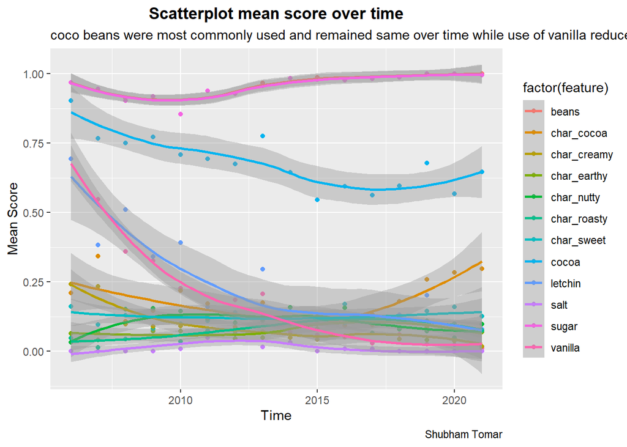

```r
###Part 4
p <- qplot(x= review_date, y= mean_score, data= ans3_pivot, color = factor(feature), geom = c("point", "smooth"), xlab= "Time", ylab= "Mean Score", main = "Scatterplot mean score over time")
p + theme(plot.title = element_text(face = "bold", hjust = 0.5)) + labs(subtitle= "coco beans were most commonly used and remained same over time while use of vanilla reduced over years.",
caption = "Shubham Tomar")
```

# Part 5: Make the worst plot you can!

This sounds a bit crazy I know, but I want this to try and be FUN! Instead of trying to make a “good” plot, I want you to explore your creative side and make a really awful data visualization in every way. :)

### Tasks

Using the `chocolate` dataset (or any of the modified versions you made throughout this assignment or anything else you wish you build upon it):

1. Make the absolute worst plot that you can. You need to customize it in **at least 7 ways** to make it awful.
2. In your document, write 1 - 2 sentences about each different customization you added (using bullets – i.e. there should be at least 7 bullet points each with 1-2 sentences), and how it could be useful for you when you want to make an awesome data visualization.

[output not shown]

[output not shown]

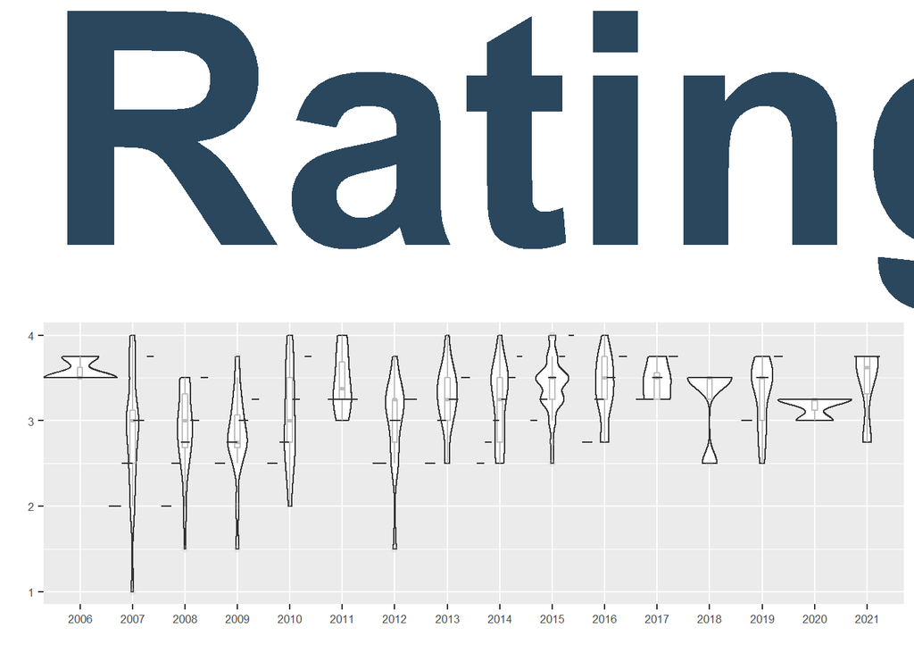

```r
###Part 5
wp<- ecu %>% ggplot(aes(x= as.factor(review_date), y= rating)) + geom_violin() + geom_violin(draw_quantiles = c(.25, .50, .75)) + geom_violin(width=1.4) +
    geom_boxplot(width=0.1, color="grey", alpha=0.2) +
    theme(
      legend.position="none",
      plot.title = element_text(size=11)
    ) +
    ggtitle("Rating over time") +
    xlab("") + ylab("") +
    geom_violin(aes(fill= factor(rating))) +
    theme(
    text = element_text(family = "Roboto", size = 8, color = "black"),
    plot.title = element_text(
      family = "Lobster Two",
      size = 180,
      face = "bold",
      color = "#2a475e"
    ))
wp
```

```r
#Not a good plot because
#1. Big title, out of scale
#2. No legend
#3. No axis title
#4. No subtitle or information
#5. Grayscale / colour scheme
#6. Bins
#7. Font sizes
```

# Part 6: Make my plot a better plot!

The goal is to take my sad looking plot and make it better! If you’d like an [example](https://twitter.com/drmowinckels/status/1392136510468763652), here is a tweet I came across of someone who gave a talk about how to zhoosh up your ggplots.

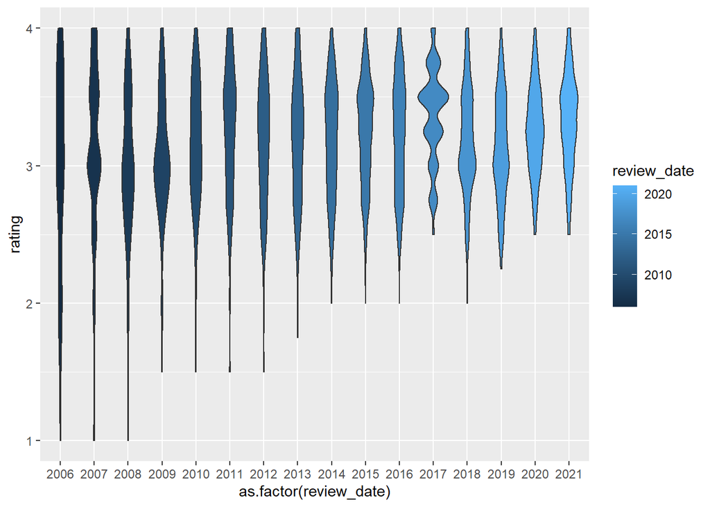

```r
chocolate %>%
  ggplot(aes(x = as.factor(review_date),
             y = rating,
             fill = review_date)) +
  geom_violin()
```

### Tasks

1. You need to customize it in **at least 7 ways** to make it better.
2. In your document, write 1 - 2 sentences about each different customization you added (using bullets – i.e. there should be at least 7 bullet points each with 1-2 sentences), describing how you improved it.

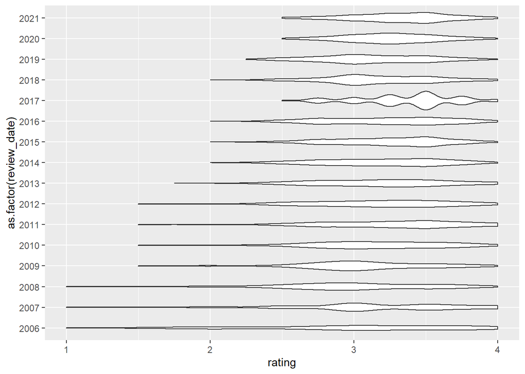

```r
###Part 6

#generate voilen plot
imp<- chocolate %>% ggplot(aes(x = as.factor(review_date),  y = rating))

#1. Flip side
imp + geom_violin() + coord_flip()
```

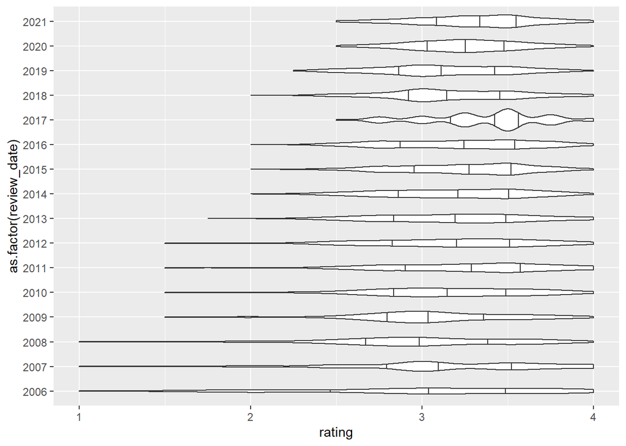

```r
#2. Add quintiles
imp +geom_violin() + coord_flip() + geom_violin(draw_quantiles = c(.25, .50, .75))
```

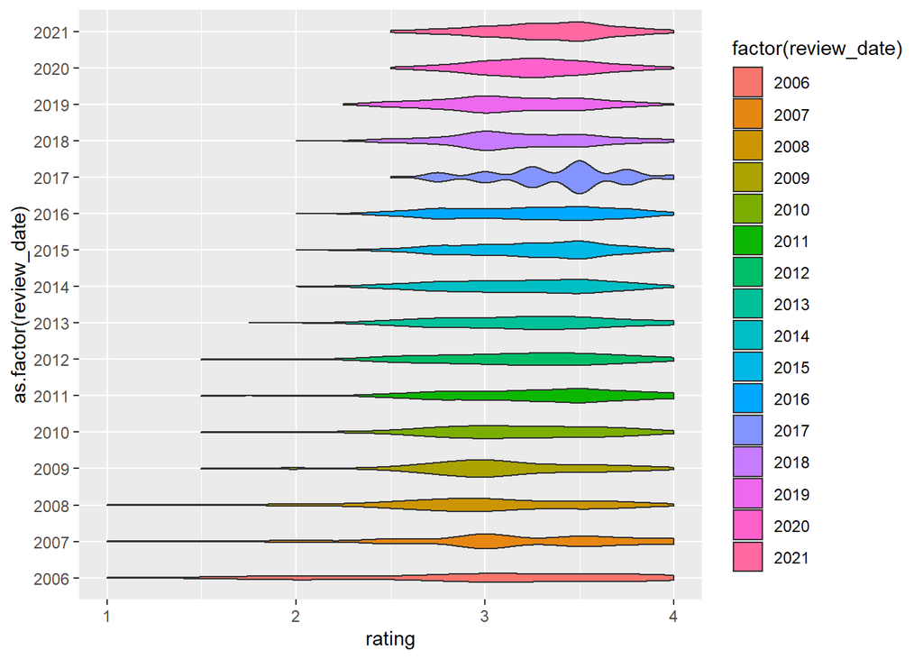

```r
#3. Add colour
imp +geom_violin() + coord_flip() + geom_violin(draw_quantiles = c(.25, .50, .75)) + geom_violin(aes(fill= factor(review_date)))
```

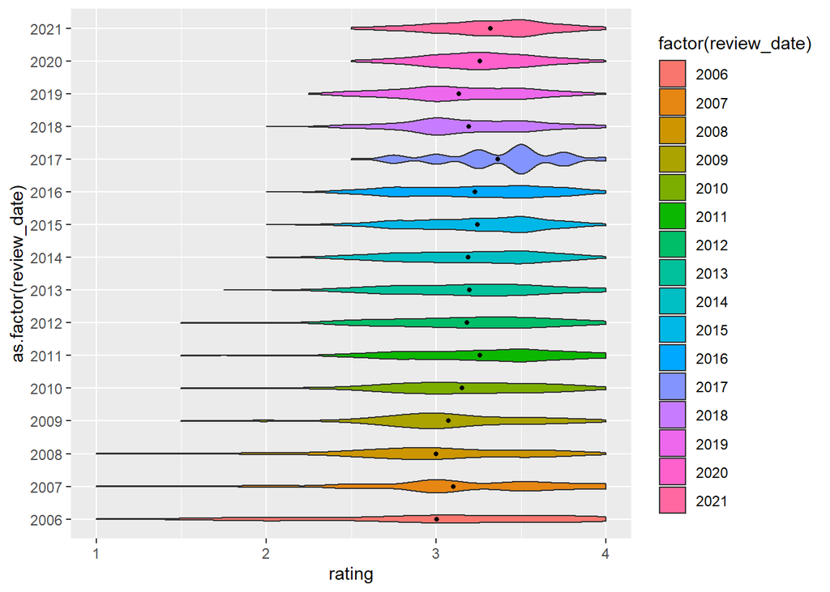

```r
#4. Add summary mean
imp +geom_violin() + coord_flip() + geom_violin(draw_quantiles = c(.25, .50, .75)) + geom_violin(aes(fill= factor(review_date))) +stat_summary(fun="mean", geom="point", size=1, color="black")
```

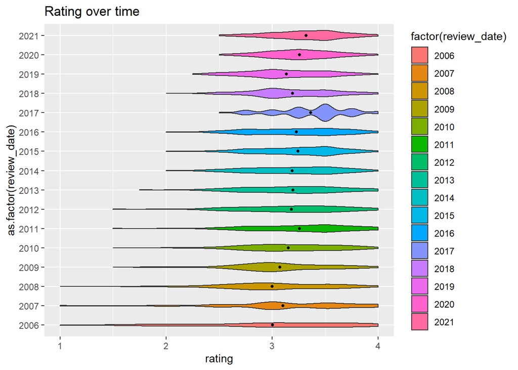

```r
#5. Add title
imp +geom_violin() + coord_flip() + geom_violin(draw_quantiles = c(.25, .50, .75)) + geom_violin(aes(fill= factor(review_date))) + stat_summary(fun="mean", geom="point", size=1, color="black") + labs(title="Rating over time")
```

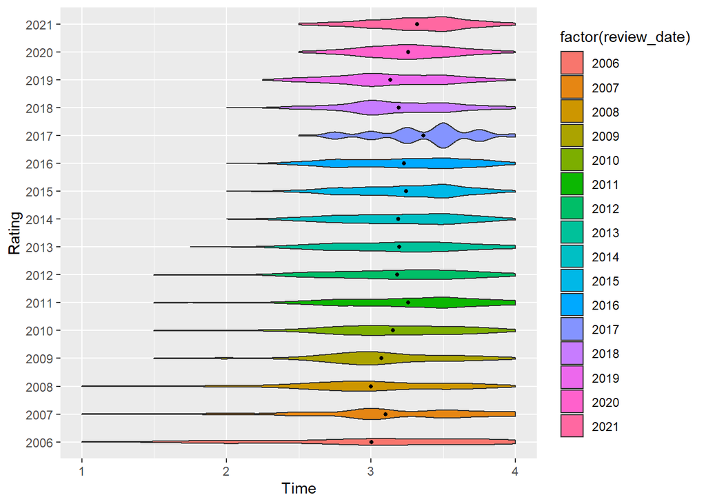

```r
#6. Adding labels
imp +geom_violin() + coord_flip() + geom_violin(draw_quantiles = c(.25, .50, .75)) + geom_violin(aes(fill= factor(review_date))) + stat_summary(fun="mean", geom="point", size=1, color="black") + xlab("Rating") +
ylab("Time")
```

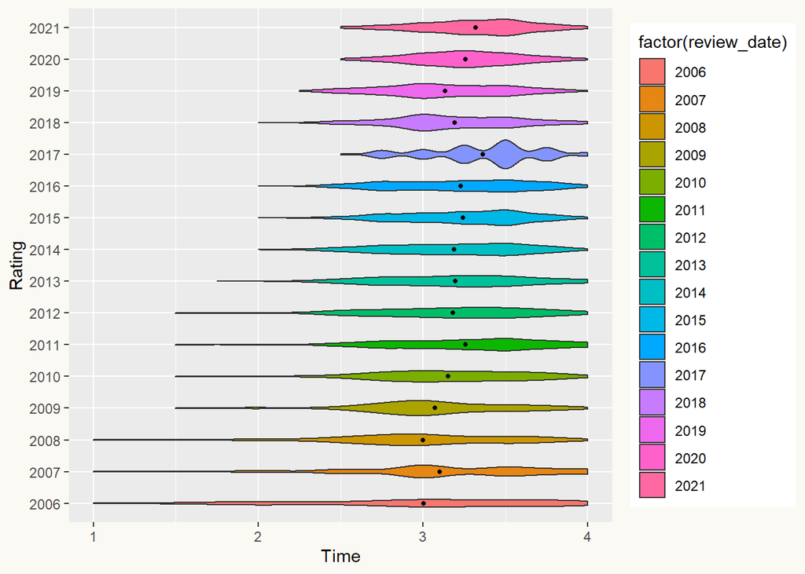

```r
#7. Background

imp +geom_violin() + coord_flip() + geom_violin(draw_quantiles = c(.25, .50, .75)) + geom_violin(aes(fill= factor(review_date))) + stat_summary(fun="mean", geom="point", size=1, color="black") + xlab("Rating") +
ylab("Time") + theme(plot.background = element_rect(fill = "#fbf9f4", color = "#fbf9f4"))
```